# Iris

Rafael Lisboa - 345728 | Lucas - 345229 | Vinicius - 345477 | Frank - 344163

2022-06-26

### **Importando as bibliotecas**

```r
library("ggplot2")
```

### **Importando a base de dados**

```r
iris <- read.csv("https://gist.githubusercontent.com/netj/8836201/raw/6f9306ad21398ea43cba4f7d537619d0e07d5ae3/iris.csv")
```

# Conjunto de dados flor Iris

*Origem: Wikipédia, a enciclopédia livre.*

#### Diferenças entre flores de Íris

> O conjunto de dados flor Iris ou conjunto de dados Iris de Fisher é um conjunto de dados multivariados introduzido pelo estatístico e biólogo britânico Ronald Fisher em seu artigo de 1936, O uso de múltiplas medições em problemas taxonômicos, como um exemplo de análise discriminante linear. Às vezes, é chamado de conjunto de dados da íris de Anderson porque Edgar Anderson coletou os dados para quantificar a variação morfológica das flores da íris de três espécies relacionadas. Duas das três espécies foram coletadas na Península de Gaspé, “todas do mesmo campo, colhidas no mesmo dia e medidas ao mesmo tempo pela mesma pessoa com a mesma aparelho”. O conjunto de dados consiste em 50 amostras de cada uma das três espécies de Iris ( Iris setosa, Iris virginica e Iris versicolor). Quatro variáveis foram medidas em cada amostra: o comprimento e a largura das sépalas e pétalas, em centímetros. Com base na combinação dessas quatro características, Fisher desenvolveu um modelo discriminante linear para distinguir as espécies umas das outras.

## Iris sépala comprimento por largura

#### *Plot do **comprimento da sépala** pela* **largura da sépala** de cada variedade de Iris

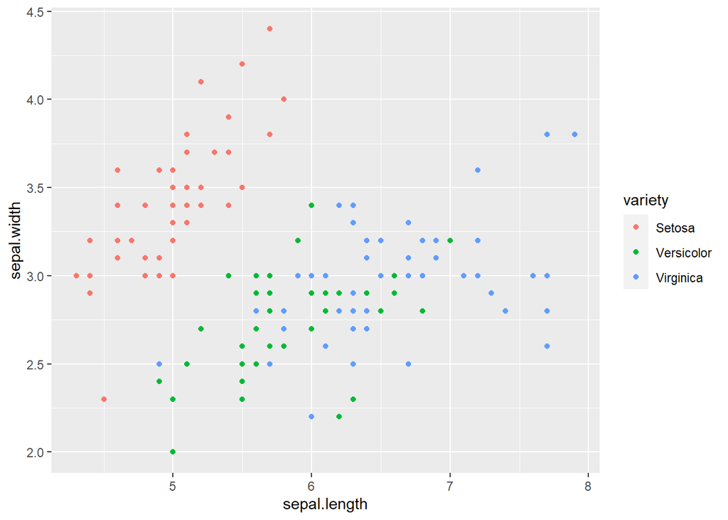

```r
ggplot(iris)+geom_point(mapping = aes(x =  sepal.length,
                                      y = sepal.width,color=variety))
```

## Iris pétala comprimento por largura

#### *Plot do **comprimento da pétala** pela* **largura da pétala** *de cada variedade de Iris*

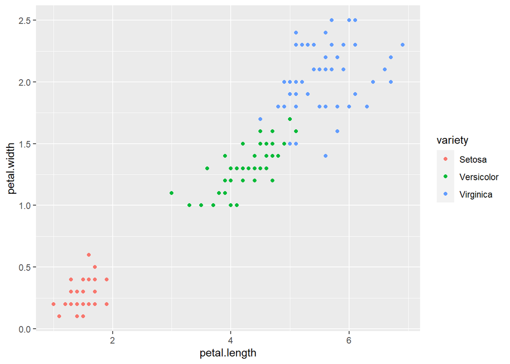

```r
ggplot(iris)+geom_point(mapping = aes(x =  petal.length,
                                      y = petal.width,color=variety))
```

## Iris boxsplot

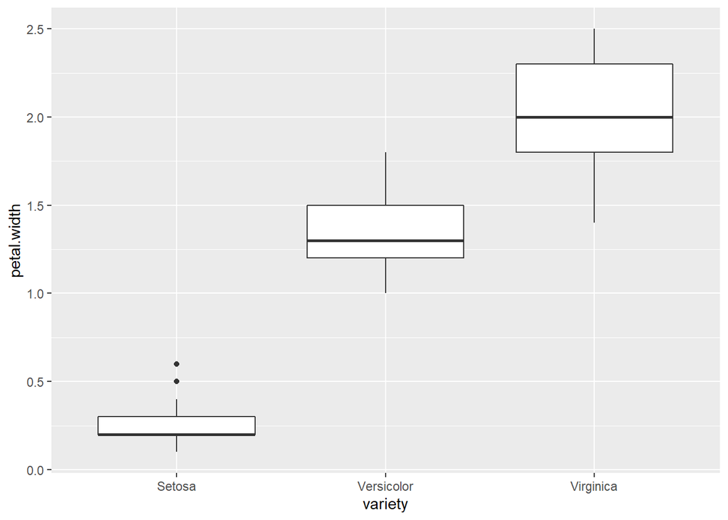

```r
ggplot(iris)+geom_boxplot(mapping = aes(x = variety,
                                        y = petal.width))
```